# Sesión aplicada: gráficos y tablas en Quarto

Sesión del lunes, 9 de noviembre de 2026

# 1 Visualizar datos

Esta hoja de código Quarto contiene ejemplos de cómo generar gráficos y tablas en R, utilizando diferentes librerías y funciones. Además, se muestran algunas opciones para insertar y referenciar estos elementos dentro de un documento Quarto.

# 2 Datos del ejemplo: LAPOP

En esta ocasión trabajaremos con un subconjunto de datos previamente procesados derivados de las encuestas realizadas en diferentes países por el [Latin American Public Opinion Proyect (LAPOP)](https://www.vanderbilt.edu/lapop/) en su ola del 2018. Para este ejercicio, obtendremos directamente esta base desde internet. No obstante, también tienes la opción de acceder a la misma información a través del siguiente enlace: [`LAPOP 2018`](https://github.com/cursos-metodos-facso/datos-ejemplos/raw/main/lapop_proc_2018.RData). Desde allí, podrás descargar el archivo que contiene el subconjunto procesado de la base de datos LAPOP 2018.

- Comencemos por preparar nuestros datos. Iniciamos cargando las librerías necesarias.

```r
pacman::p_load(tidyverse, # Manipulacion datos
               ggplot2, # Gráficos
               sjPlot, # Tablas y gráficos
               ggpubr) # Gráficos

options(scipen = 999) # para desactivar notacion cientifica
rm(list = ls()) # para limpiar el entorno de trabajo
```

- Cargamos los datos desde internet.

```r
load(url("https://github.com/cursos-metodos-facso/datos-ejemplos/raw/main/lapop_proc_2018.RData")) #Cargar base de datos
```

- A continuación, exploramos la base de datos.

```r
names(lapop) # Nombre de columnas
```

```
 [1] "year"        "pais"        "pais_name"   "idnum"       "upm"
 [6] "strata"      "wt"          "weight1500"  "sexo"        "edad"
[11] "educ"        "l1"          "ideologia_f" "empleo"      "decile"
[16] "it1"         "prot3"       "aoj12"       "b2"          "b3"
[21] "b4"          "b10a"        "b12"         "b20"         "b20a"
[26] "b21"         "b21a"        "n9"          "n11"         "n15"
[31] "ros4"        "ing4"        "eff1"        "pn4"         "exc7"
[36] "pol1"        "vb2"         "gini"        "gdp"
```

```r
dim(lapop) # Dimensiones
```

```
[1] 23386    39
```

Contamos con 39 variables (columnas) y 23.386 observaciones (filas). Seleccionamos las variables que vamos a utilizar en nuestro ejemplo:

```r
lapop <- lapop %>% dplyr::select(pais, sexo, edad, decile, ideologia_f, ros4, prot3, it1, gini, gdp) # Seleccionamos variables de interes
```

**Distribución de la variable central de estudio**: preferencia por la redistribución (`ros4`).

```r
sjmisc::frq(lapop$ros4)
```

```
Gobierno debe Implementar Políticas para Reducir Desigualdadad de Ingresos (x) <numeric>
# total N=23386 valid N=23111 mean=5.31 sd=1.77

Value |             Label |    N | Raw % | Valid % | Cum. %
-----------------------------------------------------------
    1 | Muy en desacuerdo | 1198 |  5.12 |    5.18 |   5.18
    2 |                 2 |  899 |  3.84 |    3.89 |   9.07
    3 |                 3 | 1650 |  7.06 |    7.14 |  16.21
    4 |                 4 | 3033 | 12.97 |   13.12 |  29.34
    5 |                 5 | 3880 | 16.59 |   16.79 |  46.13
    6 |                 6 | 3882 | 16.60 |   16.80 |  62.92
    7 |    Muy de acuerdo | 8569 | 36.64 |   37.08 | 100.00
 <NA> |              <NA> |  275 |  1.18 |    <NA> |   <NA>
```

# 3 Gráficos

## 3.1 Visualización de datos con `ggplot2`

### 3.1.1 Diferencias de medias (o proporciones) entre grupos

Media de preferencia por la redistribución según ideología política.

```r
db_g1 <- lapop %>%
  group_by(ideologia_f) %>%
  summarise(
    media_ros4 = mean(ros4, na.rm = TRUE),
    error_std = sd(ros4, na.rm = TRUE) / sqrt(n()),
    ci_inf = media_ros4 - qt(0.975, df = n() - 1) * error_std,
    ci_sup = media_ros4 + qt(0.975, df = n() - 1) * error_std
  ) %>%
  na.omit()

db_g1
## # A tibble: 4 × 5
##   ideologia_f  media_ros4 error_std ci_inf ci_sup
##   <fct>             <dbl>     <dbl>  <dbl>  <dbl>
## 1 Derecha            5.34    0.0222   5.29   5.38
## 2 Centro             5.40    0.0199   5.36   5.44
## 3 Izquierda          5.33    0.0220   5.29   5.37
## 4 No declarado       5.05    0.0327   4.98   5.11
```

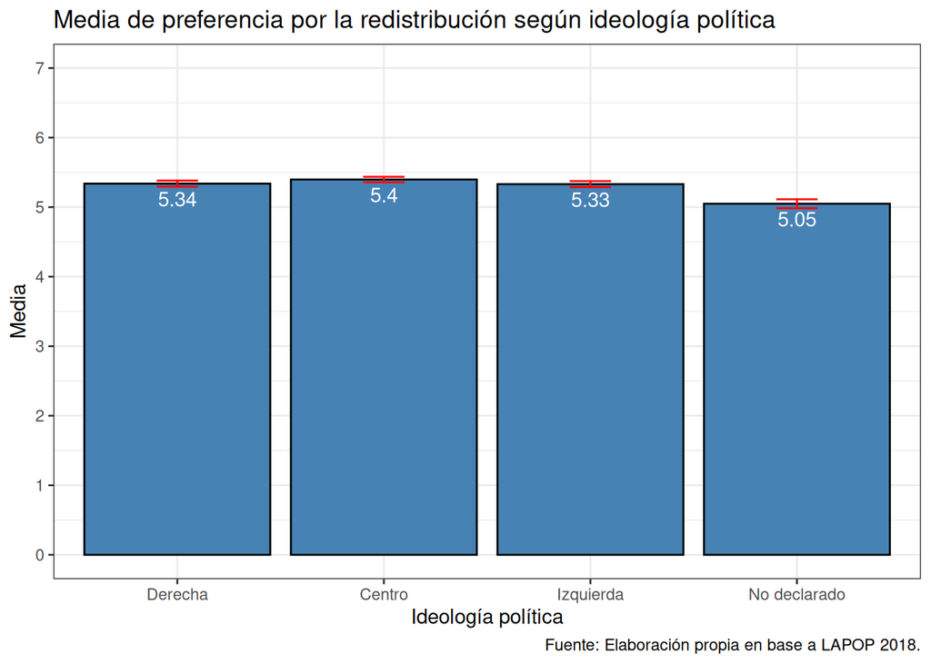

```r
ggplot(data = db_g1,
       mapping = aes(x = ideologia_f, y = media_ros4, group = ideologia_f)) + # especificamos datos y mapping
  geom_bar(stat = "identity", color = "black", fill = "steelblue") + # agregamos geometria
  geom_errorbar(aes(ymin = ci_inf, ymax = ci_sup), width = 0.2, color = "red") + # agregamos intervalo de confianza calculado previamente
  scale_y_continuous(limits = c(0,7), n.breaks = 7) + # agregamos escala en eje Y y ponemos limites minimos y maximos
  geom_text(aes(label = round(media_ros4,2)), vjust = 1.5, colour = "white") + # agregamos los valores de la media para cada barra/grupo
  labs(title ="Media de preferencia por la redistribución según ideología política",
       x = "Ideología política",
       y = "Media",
       caption = "Fuente: Elaboración propia en base a LAPOP 2018.") + # agregamos titulo, nombres a los ejes y fuente
  theme_bw() # especificamos tema
```

### 3.1.2 Asociación entre continuas

Asociación entre la preferencia por la redistribución de los países y su nivel de desigualdad económica.

```r
db_g2 <- lapop %>%
  group_by(pais) %>%
  summarise(cm_ros4 = mean(ros4, na.rm = T),
            cm_gini = mean(gini, na.rm = T)) %>%
  ungroup()

head(db_g2)
## # A tibble: 6 × 3
##   pais  cm_ros4 cm_gini
##   <chr>   <dbl>   <dbl>
## 1 ARG      5.43    41.1
## 2 BOL      4.72    44.6
## 3 BRA      5.43    53.3
## 4 CHL      5.69    44.4
## 5 COL      5.37    49.7
## 6 CRI      6.05    48.3
```

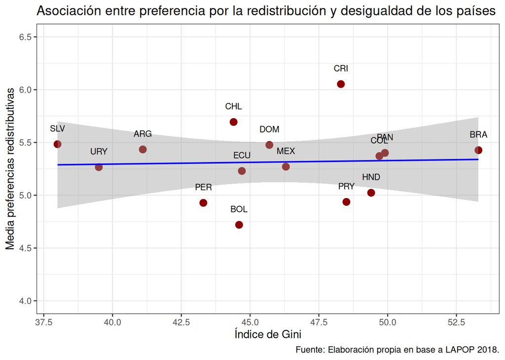

```r
ggplot(data = db_g2,
       mapping = aes(x = cm_gini, y = cm_ros4)) + # especificamos datos y mapping
  geom_point(size = 3, color = "darkred") + # agregamos geometria y color
  geom_smooth(stat = "smooth", position = "identity", method = "lm",
              colour = "blue", size = 0.7) + # agregamos recta que representa la correlacion
  scale_y_continuous(limits = c(4,6.5), breaks = seq(4,6.5, by = 0.5)) + # agregamos escala en eje Y y ponemos limites minimos y maximos
  scale_x_continuous(n.breaks = 7) +  # agregamos escala eje X para mostrar más valores
  geom_text(aes(label = pais), size = 3, color = "black",
            nudge_y = 0.15) + # agregamos etiquetas de país
  labs(title ="Asociación entre preferencia por la redistribución y desigualdad de los países",
       y = "Media preferencias redistributivas",
       x = "Índice de Gini",
       caption = "Fuente: Elaboración propia en base a LAPOP 2018.") + # agregamos titulo, nombres a los ejes y fuente
  theme_bw() # especificamos tema
```

### 3.1.3 Asociación entre categóricas

Asociación entre la participación en protestas y la ideología política. Usamos barras apiladas que suman 100%, calculando los porcentajes en dos direcciones.

#### 3.1.3.1 Con `ggplot2`

```r
db_g3 <- lapop %>%
  dplyr::select(prot3, ideologia_f) %>%
  na.omit()

# Porcentajes que suman 100% dentro de cada ideología
db_g3a <- db_g3 %>%
  count(ideologia_f, prot3) %>% # frecuencias por combinación de categorías
  group_by(ideologia_f) %>%
  mutate(prop = n / sum(n) * 100)

# Porcentajes que suman 100% dentro de cada categoría de participación
db_g3b <- db_g3 %>%
  count(prot3, ideologia_f) %>%
  group_by(prot3) %>%
  mutate(prop = n / sum(n) * 100)

db_g3a
## # A tibble: 8 × 4
## # Groups:   ideologia_f [4]
##   ideologia_f  prot3     n  prop
##   <fct>        <fct> <int> <dbl>
## 1 Derecha      Sí      872 12.8
## 2 Derecha      No     5933 87.2
## 3 Centro       Sí      587  8.83
## 4 Centro       No     6058 91.2
## 5 Izquierda    Sí      577  8.96
## 6 Izquierda    No     5864 91.0
## 7 No declarado Sí      299  8.66
## 8 No declarado No     3154 91.3
db_g3b
## # A tibble: 8 × 4
## # Groups:   prot3 [2]
##   prot3 ideologia_f      n  prop
##   <fct> <fct>        <int> <dbl>
## 1 Sí    Derecha        872  37.3
## 2 Sí    Centro         587  25.1
## 3 Sí    Izquierda      577  24.7
## 4 Sí    No declarado   299  12.8
## 5 No    Derecha       5933  28.2
## 6 No    Centro        6058  28.8
## 7 No    Izquierda     5864  27.9
## 8 No    No declarado  3154  15.0
```

**% por ideología**: ¿qué proporción de cada grupo ideológico participó en protestas?

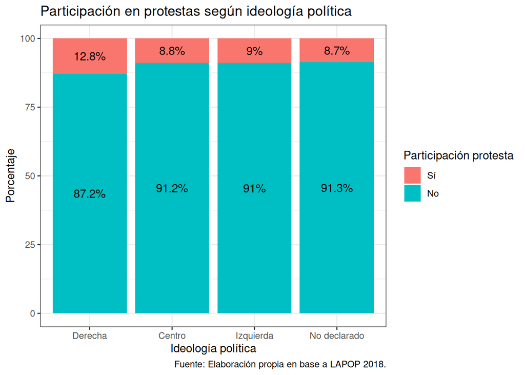

```r
ggplot(data = db_g3a,
       mapping = aes(x = ideologia_f, y = prop, fill = prot3)) +
  geom_col() + # barras apiladas que suman 100%
  geom_text(aes(label = paste0(round(prop, 1), "%")),
            position = position_stack(vjust = 0.5)) + # porcentajes al centro de cada segmento
  labs(title = "Participación en protestas según ideología política",
       y = "Porcentaje",
       x = "Ideología política",
       fill = "Participación protesta",
       caption = "Fuente: Elaboración propia en base a LAPOP 2018.") + # agregamos titulo, nombres a los ejes y fuente
  theme_bw() # especificamos tema
```

**% por participación**: ¿cuál es la composición ideológica de quienes participan y de quienes no?

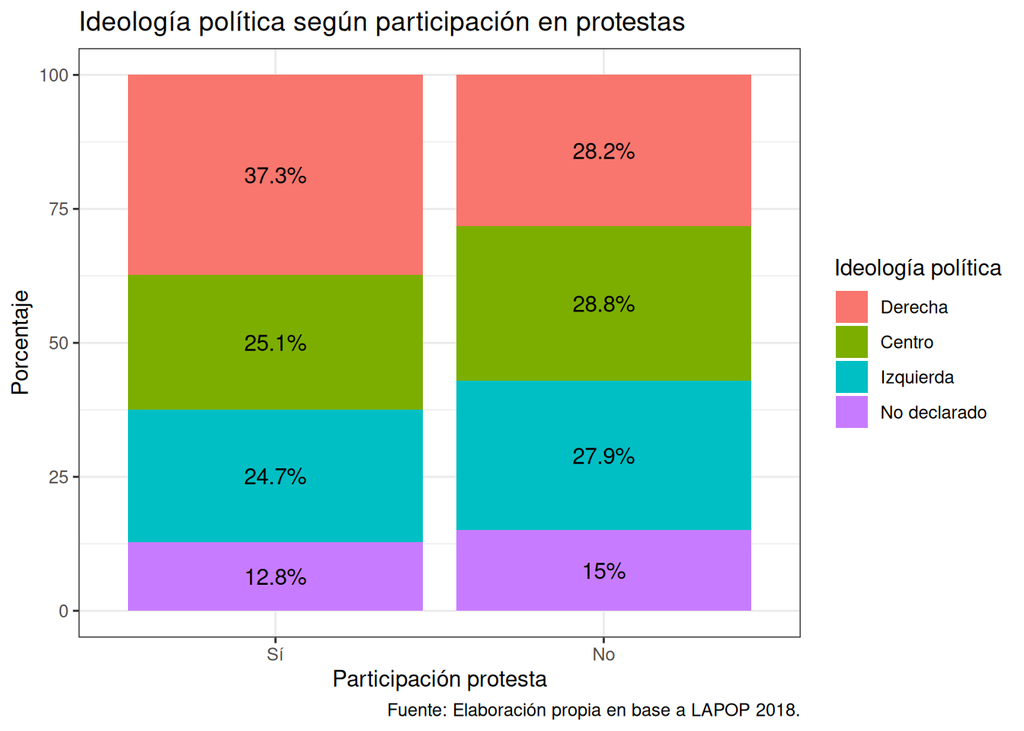

```r
ggplot(data = db_g3b,
       mapping = aes(x = prot3, y = prop, fill = ideologia_f)) +
  geom_col() +
  geom_text(aes(label = paste0(round(prop, 1), "%")),
            position = position_stack(vjust = 0.5)) +
  labs(title = "Ideología política según participación en protestas",
       y = "Porcentaje",
       x = "Participación protesta",
       fill = "Ideología política",
       caption = "Fuente: Elaboración propia en base a LAPOP 2018.") + # agregamos titulo, nombres a los ejes y fuente
  theme_bw() # especificamos tema
```

## 3.2 Visualización con otras librerías

### 3.2.1 Con `ggpubr`

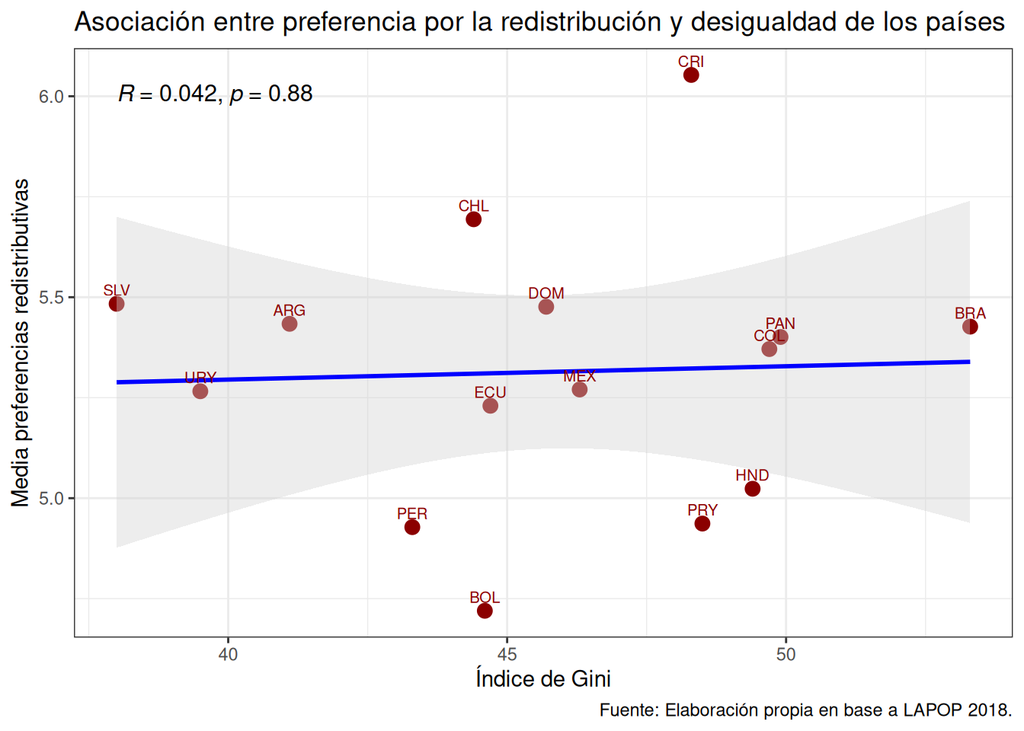

```r
ggscatter(data = db_g2,
          x = "cm_gini",
          y = "cm_ros4",
          color = "darkred",
          cor.coef = T, # mostrar coef corr
          cor.coef.size = 4, # tamaño texto coef corr
          add = "reg.line",  # mostrar linea de reg
          conf.int = T,  # mostrar SE
          add.params = list(color = "blue", fill = "lightgray"), # colores
          label = "pais",
          size = 3,
          font.label = c(8, "plain")
) +
  labs(title ="Asociación entre preferencia por la redistribución y desigualdad de los países",
       y = "Media preferencias redistributivas",
       x = "Índice de Gini",
       caption = "Fuente: Elaboración propia en base a LAPOP 2018.") + # agregamos titulo, nombres a los ejes y fuente
  theme_bw() # especificamos tema
```

### 3.2.2 Con `sjPlot`

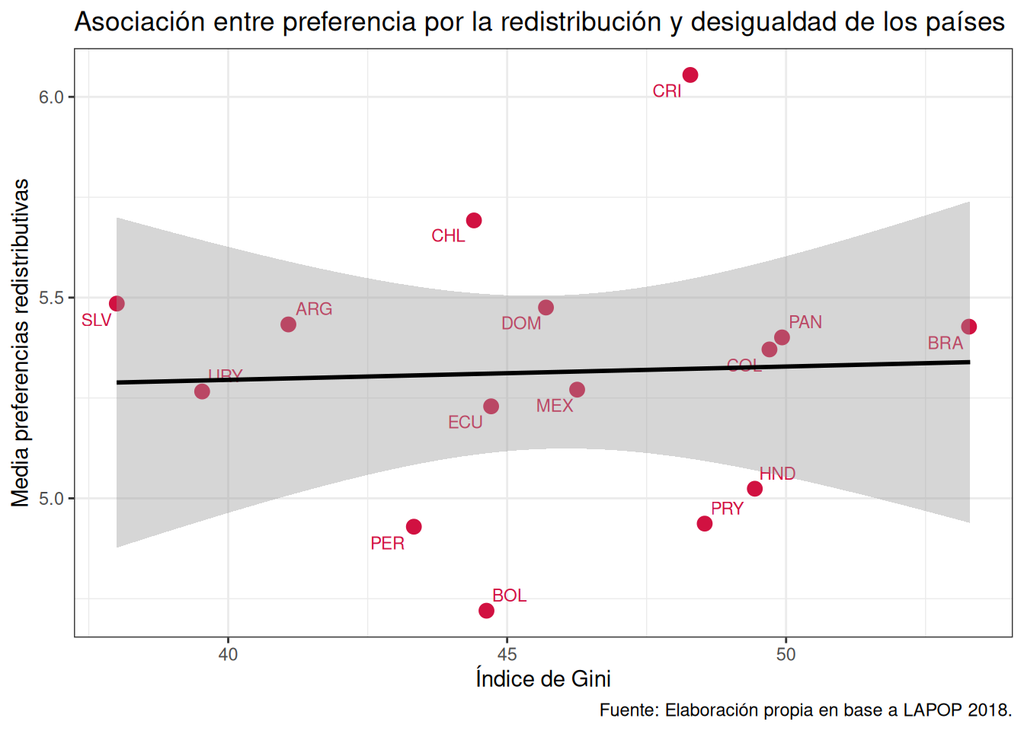

```r
sjPlot::plot_scatter(
  data = db_g2,
  x = cm_gini,
  y = cm_ros4,
  fit.line = "lm",      # Mostrar línea de regresión
  show.ci = TRUE,       # Mostrar intervalo de confianza
  dot.size = 3,
  dot.labels = db_g2$pais # Etiquetas de los puntos
) +
  labs(title ="Asociación entre preferencia por la redistribución y desigualdad de los países",
       y = "Media preferencias redistributivas",
       x = "Índice de Gini",
       caption = "Fuente: Elaboración propia en base a LAPOP 2018.") + # agregamos titulo, nombres a los ejes y fuente
  theme_bw() # especificamos tema
```

# 4 Tablas

Cargamos los paquetes para esta sección:

```r
pacman::p_load(tidyverse, # Manipulacion datos
               sjmisc, # Descriptivos
               knitr, # Render y tablas
               kableExtra, # Formateo tablas
               summarytools, # Tablas
               sjPlot, # Tablas y gráficos
               stargazer, # Tablas
               janitor, # Tablas y formateo
               crosstable, # Tablas
               table1 # Tablas
               )
```

## 4.1 Tablas con `kable` y `kableExtra`

### Confianza interpersonal según país

1. Creamos el objeto `tab1` con el contenido de la tabla

```r
tab1 <- lapop %>%
  group_by(pais, it1) %>% # agrupamos por pais y variable
  summarise(n = n()) %>% # contamos por categ de respuesta
  mutate(prop = round((n / sum(n)) * 100, 2)) %>% # porcentaje
  na.omit() %>% # borramos NA
  pivot_wider(id_cols = pais, names_from = it1, values_from = prop) # convertimos a formato ancho

tab1
```

```
# A tibble: 15 × 5
# Groups:   pais [15]
   pais    `1`   `2`   `3`   `4`
   <chr> <dbl> <dbl> <dbl> <dbl>
 1 ARG    7.98  21.7  45.1  23.2
 2 BOL   13.6   40.5  31.9  11.6
 3 BRA   12.9   45.4  19.8  19.8
 4 CHL   10.6   23.4  40.5  24.6
 5 COL    9.14  25.7  34.4  29.0
 6 CRI    8.53  22.6  34.6  32.2
 7 DOM   11.3   29.0  31.3  24.0
 8 ECU   11.7   37.8  32.2  17.3
 9 HND   14.0   28.6  22.8  29.3
10 MEX   11.2   33.2  31.5  20.7
11 PAN   14.2   34    31.5  18.5
12 PER   14.9   42.3  31.2  10.6
13 PRY    9.7   24.1  35.6  26.9
14 SLV    8.6   32.3  26.3  29.2
15 URY    7.08  18.7  43.8  27.1
```

2. Aplicamos el formato con `kable()` y `kableExtra`

```r
tabla1 <- tab1 %>%
  kable(format = "markdown",
        align = "c",
        col.names = c("País", "Nada confiable", "Poco confiable", "Algo confiable", "Muy confiable"),
        caption = "Tabla 1. Confianza interpersonal según país") %>%
  kableExtra::kable_classic(full_width = FALSE, position = "center", font_size = 14) %>%
  kableExtra::add_footnote(label = "Fuente: Elaboración propia en base a LAPOP 2018.")

tabla1
```

Tabla 1. Confianza interpersonal según país

| País | Nada confiable | Poco confiable | Algo confiable | Muy confiable |
| --- | --- | --- | --- | --- |
| ARG | 7.98 | 21.66 | 45.09 | 23.23 |
| BOL | 13.56 | 40.49 | 31.87 | 11.59 |
| BRA | 12.88 | 45.39 | 19.76 | 19.76 |
| CHL | 10.56 | 23.44 | 40.54 | 24.60 |
| COL | 9.14 | 25.74 | 34.40 | 28.98 |
| CRI | 8.53 | 22.58 | 34.64 | 32.25 |
| DOM | 11.28 | 29.02 | 31.27 | 24.01 |
| ECU | 11.68 | 37.83 | 32.22 | 17.29 |
| HND | 14.04 | 28.65 | 22.82 | 29.29 |
| MEX | 11.20 | 33.16 | 31.46 | 20.70 |
| PAN | 14.24 | 34.00 | 31.49 | 18.47 |
| PER | 14.92 | 42.34 | 31.23 | 10.59 |
| PRY | 9.70 | 24.09 | 35.64 | 26.86 |
| SLV | 8.60 | 32.30 | 26.27 | 29.19 |
| URY | 7.08 | 18.72 | 43.77 | 27.07 |

<sup>a</sup> Fuente: Elaboración propia en base a LAPOP 2018.

### Descriptivos de edad según país

1. Creamos el objeto `tab2` con los estadísticos descriptivos de `edad` por país

```r
tab2 <- lapop %>%
  group_by(pais) %>%
  summarise(
    n = n(), # Tamaño muestral
    min = min(edad, na.rm = T), # Mínimo
    max = max(edad, na.rm = T), # Máximo
    media = round(mean(edad, na.rm = T), 2), # Media redondeada a 2 digitos
    sd = round(sd(edad, na.rm = T), 2), # Desviación estándar redondeada a 2 digitos
    mediana = median(edad, na.rm = T) # Mediana
  )
```

2. Aplicamos el formato con `kable()` y `kableExtra`

```r
tabla2 <- tab2 %>%
  kable(format = "markdown",
        align = "c",
        col.names = c("País", "Tamaño muestral", "Mínimo", "Máximo", "Media", "Desv. estándar", "Mediana"),
        caption = "Tabla 2. Edad según país") %>%
  kableExtra::kable_classic(full_width = FALSE, position = "center", font_size = 14) %>%
  kableExtra::add_footnote(label = "Fuente: Elaboración propia en base a LAPOP 2018.")

tabla2
```

Tabla 2. Edad según país

| País | Tamaño muestral | Mínimo | Máximo | Media | Desv. estándar | Mediana |
| --- | --- | --- | --- | --- | --- | --- |
| ARG | 1528 | 16 | 90 | 41.84 | 17.75 | 39.0 |
| BOL | 1682 | 18 | 89 | 39.52 | 16.30 | 36.0 |
| BRA | 1498 | 16 | 92 | 39.15 | 16.25 | 37.0 |
| CHL | 1638 | 18 | 92 | 42.22 | 16.80 | 40.0 |
| COL | 1663 | 18 | 90 | 40.36 | 16.33 | 37.0 |
| CRI | 1501 | 18 | 89 | 40.50 | 16.88 | 37.0 |
| DOM | 1516 | 18 | 87 | 40.05 | 16.98 | 37.0 |
| ECU | 1533 | 16 | 92 | 38.16 | 17.10 | 35.0 |
| HND | 1560 | 18 | 89 | 38.17 | 16.26 | 34.0 |
| MEX | 1580 | 18 | 88 | 42.09 | 17.03 | 40.0 |
| PAN | 1559 | 18 | 93 | 39.56 | 16.17 | 37.5 |
| PER | 1521 | 18 | 91 | 38.85 | 15.54 | 36.0 |
| PRY | 1515 | 18 | 87 | 40.00 | 16.28 | 37.0 |
| SLV | 1511 | 18 | 99 | 39.99 | 16.62 | 38.0 |
| URY | 1581 | 18 | 95 | 46.19 | 17.89 | 44.0 |

<sup>a</sup> Fuente: Elaboración propia en base a LAPOP 2018.

## 4.2 Funciones automatizadas para la construcción de tablas

```r
# Creemos una version de lapop solo con algunas variables como ejemplo
data_example <- lapop %>%
  select(pais, it1, edad, sexo, gini, gdp)
```

### 4.2.1 Funciones para tablas univariadas

#### 4.2.1.1 `summarytools`

```r
tab <- summarytools::dfSummary(data_example)
summarytools::view(tab, method = "render")
```

Data Frame Summary

data_example

**Dimensions**: 23386 x 6  
**Duplicates**: 16464

| **No** | **Variable** | **Label** | **Stats / Values** | **Freqs (% of Valid)** | **Graph** | **Valid** | **Missing** |
| --- | --- | --- | --- | --- | --- | --- | --- |
| 1 | pais [character] | País | 1. BOL 2. COL 3. CHL 4. URY 5. MEX 6. HND 7. PAN 8. ECU 9. ARG 10. PER [ 5 others ] | 1682 ( 7.2% ) 1663 ( 7.1% ) 1638 ( 7.0% ) 1581 ( 6.8% ) 1580 ( 6.8% ) 1560 ( 6.7% ) 1559 ( 6.7% ) 1533 ( 6.6% ) 1528 ( 6.5% ) 1521 ( 6.5% ) 7541 ( 32.2% ) |  | 23386 (100.0%) | 0 (0.0%) |
| 2 | it1 [numeric] | Confianza Interpersonal | Mean (sd) : 2.7 (1) min ≤ med ≤ max: 1 ≤ 3 ≤ 4 IQR (CV) : 1 (0.4) | 1 : 2580 ( 11.3% ) 2 : 7157 ( 31.4% ) 3 : 7693 ( 33.8% ) 4 : 5353 ( 23.5% ) |  | 22783 (97.4%) | 603 (2.6%) |
| 3 | edad [numeric] | Edad | Mean (sd) : 40.5 (16.8) min ≤ med ≤ max: 16 ≤ 38 ≤ 99 IQR (CV) : 25 (0.4) | 81 distinct values |  | 23372 (99.9%) | 14 (0.1%) |
| 4 | sexo [factor] | Sexo | 1. Hombre 2. Mujer | 11634 ( 49.8% ) 11739 ( 50.2% ) |  | 23373 (99.9%) | 13 (0.1%) |
| 5 | gini [numeric] | Índice de Gini | Mean (sd) : 45.8 (4) min ≤ med ≤ max: 38 ≤ 45.7 ≤ 53.3 IQR (CV) : 6.1 (0.1) | 15 distinct values |  | 23386 (100.0%) | 0 (0.0%) |
| 6 | gdp [numeric] | PIB per cápita | Mean (sd) : 8.7 (4.3) min ≤ med ≤ max: 2.5 ≤ 8 ≤ 16 IQR (CV) : 7.2 (0.5) | 15 distinct values |  | 23386 (100.0%) | 0 (0.0%) |

Generated by summarytools 1.0.1 ([R](https://www.r-project.org/) version 4.5.0)  
2026-11-08

```r
tab <- summarytools::descr(data_example$edad)
summarytools::view(tab, method = "render")
```

Descriptive Statistics

data_example$edad

**Label**: Edad  
**N**: 23386

|  | edad |
| --- | --- |
| **Mean** | 40.46 |
| **Std.Dev** | 16.80 |
| **Min** | 16.00 |
| **Q1** | 27.00 |
| **Median** | 38.00 |
| **Q3** | 52.00 |
| **Max** | 99.00 |
| **MAD** | 17.79 |
| **IQR** | 25.00 |
| **CV** | 0.42 |
| **Skewness** | 0.57 |
| **SE.Skewness** | 0.02 |
| **Kurtosis** | -0.58 |
| **N.Valid** | 23372 |
| **Pct.Valid** | 99.94 |

Generated by summarytools 1.0.1 ([R](https://www.r-project.org/) version 4.5.0)  
2026-11-08

#### 4.2.1.2 `stargazer`

```r
stargazer(as.data.frame(data_example), type = "html", summary.stat = c("mean", "sd", "min", "max"))
```

| Statistic | Mean | St. Dev. | Min | Max |
| --- | --- | --- | --- | --- |
| it1 | 2.694 | 0.953 | 1 | 4 |
| edad | 40.461 | 16.798 | 16 | 99 |
| gini | 45.778 | 4.043 | 38.000 | 53.300 |
| gdp | 8.748 | 4.278 | 2.475 | 16.038 |

#### 4.2.1.3 `psych`

```r
psych::describe(data_example) %>%
  kable() %>%
  kable_styling(full_width = TRUE)
```

|  | vars | n | mean | sd | median | trimmed | mad | min | max | range | skew | kurtosis | se |
| --- | --- | --- | --- | --- | --- | --- | --- | --- | --- | --- | --- | --- | --- |
| pais* | 1 | 23386 | 7.950911 | 4.3253391 | 8.000000 | 7.935810 | 5.930400 | 1.00000 | 15.00000 | 14.00000 | 0.0201754 | -1.2152000 | 0.0282841 |
| it1 | 2 | 22783 | 2.694333 | 0.9532423 | 3.000000 | 2.742909 | 1.482600 | 1.00000 | 4.00000 | 3.00000 | -0.1424032 | -0.9507169 | 0.0063154 |
| edad | 3 | 23372 | 40.460551 | 16.7983821 | 38.000000 | 39.158199 | 17.791200 | 16.00000 | 99.00000 | 83.00000 | 0.5674996 | -0.5770780 | 0.1098802 |
| sexo* | 4 | 23373 | 1.502246 | 0.5000057 | 2.000000 | 1.502808 | 0.000000 | 1.00000 | 2.00000 | 1.00000 | -0.0089842 | -2.0000048 | 0.0032705 |
| gini | 5 | 23386 | 45.777846 | 4.0429160 | 45.700000 | 45.896141 | 4.151280 | 38.00000 | 53.30000 | 15.30000 | -0.2035078 | -0.6251471 | 0.0264373 |
| gdp | 6 | 23386 | 8.747801 | 4.2779214 | 7.997761 | 8.634054 | 6.045964 | 2.47517 | 16.03793 | 13.56276 | 0.2534969 | -1.2525404 | 0.0279740 |

#### 4.2.1.4 `sjmisc`

```r
sjmisc::frq(data_example$it1) %>%
  kable()
```

| val | label | frq | raw.prc | valid.prc | cum.prc |
| --- | --- | --- | --- | --- | --- |
| 1 | Nada confiable | 2580 | 11.03 | 11.32 | 11.32 |
| 2 | Poco confiable | 7157 | 30.60 | 31.41 | 42.74 |
| 3 | Algo confiable | 7693 | 32.90 | 33.77 | 76.50 |
| 4 | Muy confiable | 5353 | 22.89 | 23.50 | 100.00 |
| NA | NA | 603 | 2.58 | NA | NA |

#### 4.2.1.5 `table1`

```r
table1::table1(~ factor(sexo) + edad + gini + gdp, data = data_example)
```

|  | Overall (N=23386) |
| --- | --- |
| factor(sexo) |  |
| Hombre | 11634 (49.7%) |
| Mujer | 11739 (50.2%) |
| Missing | 13 (0.1%) |
| Edad |  |
| Mean (SD) | 40.5 (16.8) |
| Median [Min, Max] | 38.0 [16.0, 99.0] |
| Missing | 14 (0.1%) |
| Índice de Gini |  |
| Mean (SD) | 45.8 (4.04) |
| Median [Min, Max] | 45.7 [38.0, 53.3] |
| PIB per cápita |  |
| Mean (SD) | 8.75 (4.28) |
| Median [Min, Max] | 8.00 [2.48, 16.0] |

### 4.2.2 Funciones para tablas bivariadas

#### 4.2.2.1 `sjPlot`

```r
sjPlot::tab_xtab(data_example$pais, data_example$it1, show.row.prc = TRUE)
```

| País | Confianza Interpersonal |  |  |  | Total |  |
| --- | --- | --- | --- | --- | --- | --- |
|  | Nada confiable | Poco confiable | Algo confiable | Muy confiable |  |  |
| ARG | 122 8.1 % | 331 22.1 % | 689 46 % | 355 23.7 % |  | 1497 100 % |
| BOL | 228 13.9 % | 681 41.5 % | 536 32.7 % | 195 11.9 % | 1640 100 % |  |
| BRA | 193 13.2 % | 680 46.4 % | 296 20.2 % | 296 20.2 % | 1465 100 % |  |
| CHL | 173 10.7 % | 384 23.6 % | 664 40.9 % | 403 24.8 % | 1624 100 % |  |
| COL | 152 9.3 % | 428 26.2 % | 572 35 % | 482 29.5 % | 1634 100 % |  |
| CRI | 128 8.7 % | 339 23 % | 520 35.4 % | 484 32.9 % | 1471 100 % |  |
| DOM | 171 11.8 % | 440 30.4 % | 474 32.7 % | 364 25.1 % | 1449 100 % |  |
| ECU | 179 11.8 % | 580 38.2 % | 494 32.5 % | 265 17.5 % | 1518 100 % |  |
| HND | 219 14.8 % | 447 30.2 % | 356 24.1 % | 457 30.9 % | 1479 100 % |  |
| MEX | 177 11.6 % | 524 34.4 % | 497 32.6 % | 327 21.4 % | 1525 100 % |  |
| PAN | 222 14.5 % | 530 34.6 % | 491 32.1 % | 288 18.8 % | 1531 100 % |  |
| PER | 227 15.1 % | 644 42.7 % | 475 31.5 % | 161 10.7 % | 1507 100 % |  |
| PRY | 147 10.1 % | 365 25 % | 540 37 % | 407 27.9 % | 1459 100 % |  |
| SLV | 130 8.9 % | 488 33.5 % | 397 27.3 % | 441 30.3 % | 1456 100 % |  |
| URY | 112 7.3 % | 296 19.4 % | 692 45.3 % | 428 28 % | 1528 100 % |  |
| Total | 2580 11.3 % | 7157 31.4 % | 7693 33.8 % | 5353 23.5 % | 22783 100 % |  |
| χ<sup>2</sup>=1306.960 · df=42 · Cramer's V=0.138 · p=0.000 |  |  |  |  |  |  |

#### 4.2.2.2 `summarytools`

```r
tab <- summarytools::ctable(data_example$pais, data_example$sexo)
summarytools::view(tab, method = "render")
```

Cross-Tabulation, Row Proportions

pais * sexo

**Data Frame**: data_example

| **pais** | sexo Hombre | sexo Hombre | sexo Hombre | sexo Hombre | sexo Mujer | sexo Mujer | sexo Mujer | sexo Mujer | sexo <NA> | sexo <NA> | sexo <NA> | sexo <NA> | Total | Total | Total | Total |
| --- | --- | --- | --- | --- | --- | --- | --- | --- | --- | --- | --- | --- | --- | --- | --- | --- |
| **ARG** | 758 | ( | 49.6% | ) | 770 | ( | 50.4% | ) | 0 | ( | 0.00% | ) | 1528 | ( | 100.0% | ) |
| **BOL** | 846 | ( | 50.3% | ) | 836 | ( | 49.7% | ) | 0 | ( | 0.00% | ) | 1682 | ( | 100.0% | ) |
| **BRA** | 748 | ( | 49.9% | ) | 750 | ( | 50.1% | ) | 0 | ( | 0.00% | ) | 1498 | ( | 100.0% | ) |
| **CHL** | 813 | ( | 49.6% | ) | 824 | ( | 50.3% | ) | 1 | ( | 0.06% | ) | 1638 | ( | 100.0% | ) |
| **COL** | 830 | ( | 49.9% | ) | 833 | ( | 50.1% | ) | 0 | ( | 0.00% | ) | 1663 | ( | 100.0% | ) |
| **CRI** | 750 | ( | 50.0% | ) | 751 | ( | 50.0% | ) | 0 | ( | 0.00% | ) | 1501 | ( | 100.0% | ) |
| **DOM** | 753 | ( | 49.7% | ) | 761 | ( | 50.2% | ) | 2 | ( | 0.13% | ) | 1516 | ( | 100.0% | ) |
| **ECU** | 760 | ( | 49.6% | ) | 764 | ( | 49.8% | ) | 9 | ( | 0.59% | ) | 1533 | ( | 100.0% | ) |
| **HND** | 778 | ( | 49.9% | ) | 782 | ( | 50.1% | ) | 0 | ( | 0.00% | ) | 1560 | ( | 100.0% | ) |
| **MEX** | 775 | ( | 49.1% | ) | 805 | ( | 50.9% | ) | 0 | ( | 0.00% | ) | 1580 | ( | 100.0% | ) |
| **PAN** | 782 | ( | 50.2% | ) | 777 | ( | 49.8% | ) | 0 | ( | 0.00% | ) | 1559 | ( | 100.0% | ) |
| **PER** | 758 | ( | 49.8% | ) | 762 | ( | 50.1% | ) | 1 | ( | 0.07% | ) | 1521 | ( | 100.0% | ) |
| **PRY** | 755 | ( | 49.8% | ) | 760 | ( | 50.2% | ) | 0 | ( | 0.00% | ) | 1515 | ( | 100.0% | ) |
| **SLV** | 755 | ( | 50.0% | ) | 756 | ( | 50.0% | ) | 0 | ( | 0.00% | ) | 1511 | ( | 100.0% | ) |
| **URY** | 773 | ( | 48.9% | ) | 808 | ( | 51.1% | ) | 0 | ( | 0.00% | ) | 1581 | ( | 100.0% | ) |
| **Total** | 11634 | ( | 49.7% | ) | 11739 | ( | 50.2% | ) | 13 | ( | 0.06% | ) | 23386 | ( | 100.0% | ) |

Generated by summarytools 1.0.1 ([R](https://www.r-project.org/) version 4.5.0)  
2026-11-08

#### 4.2.2.3 `crosstable`

```r
crosstable::crosstable(data_example, pais, by = sexo, margin=c("row", "col"), total = "both") %>%
  kable() %>%
  kable_styling(full_width = TRUE)
```

| .id | label | variable | Hombre | Mujer | NA | Total |
| --- | --- | --- | --- | --- | --- | --- |
| pais | País | ARG | 758 (6.52% / 49.61%) | 770 (6.56% / 50.39%) | 0 | 1528 (6.53%) |
| pais | País | BOL | 846 (7.27% / 50.30%) | 836 (7.12% / 49.70%) | 0 | 1682 (7.19%) |
| pais | País | BRA | 748 (6.43% / 49.93%) | 750 (6.39% / 50.07%) | 0 | 1498 (6.41%) |
| pais | País | CHL | 813 (6.99% / 49.66%) | 824 (7.02% / 50.34%) | 1 | 1638 (7.00%) |
| pais | País | COL | 830 (7.13% / 49.91%) | 833 (7.10% / 50.09%) | 0 | 1663 (7.11%) |
| pais | País | CRI | 750 (6.45% / 49.97%) | 751 (6.40% / 50.03%) | 0 | 1501 (6.42%) |
| pais | País | DOM | 753 (6.47% / 49.74%) | 761 (6.48% / 50.26%) | 2 | 1516 (6.48%) |
| pais | País | ECU | 760 (6.53% / 49.87%) | 764 (6.51% / 50.13%) | 9 | 1533 (6.56%) |
| pais | País | HND | 778 (6.69% / 49.87%) | 782 (6.66% / 50.13%) | 0 | 1560 (6.67%) |
| pais | País | MEX | 775 (6.66% / 49.05%) | 805 (6.86% / 50.95%) | 0 | 1580 (6.76%) |
| pais | País | PAN | 782 (6.72% / 50.16%) | 777 (6.62% / 49.84%) | 0 | 1559 (6.67%) |
| pais | País | PER | 758 (6.52% / 49.87%) | 762 (6.49% / 50.13%) | 1 | 1521 (6.50%) |
| pais | País | PRY | 755 (6.49% / 49.83%) | 760 (6.47% / 50.17%) | 0 | 1515 (6.48%) |
| pais | País | SLV | 755 (6.49% / 49.97%) | 756 (6.44% / 50.03%) | 0 | 1511 (6.46%) |
| pais | País | URY | 773 (6.64% / 48.89%) | 808 (6.88% / 51.11%) | 0 | 1581 (6.76%) |
| pais | País | Total | 11634 (49.78%) | 11739 (50.22%) | 13 | 23386 (100.00%) |

#### 4.2.2.4 `table1`

```r
table1::table1(~ factor(sexo) + edad + gini + gdp | pais, data = data_example)
```

|  | ARG (N=1528) | BOL (N=1682) | BRA (N=1498) | CHL (N=1638) | COL (N=1663) | CRI (N=1501) | DOM (N=1516) | ECU (N=1533) | HND (N=1560) | MEX (N=1580) | PAN (N=1559) | PER (N=1521) | PRY (N=1515) | SLV (N=1511) | URY (N=1581) | Overall (N=23386) |
| --- | --- | --- | --- | --- | --- | --- | --- | --- | --- | --- | --- | --- | --- | --- | --- | --- |
| factor(sexo) |  |  |  |  |  |  |  |  |  |  |  |  |  |  |  |  |
| Hombre | 758 (49.6%) | 846 (50.3%) | 748 (49.9%) | 813 (49.6%) | 830 (49.9%) | 750 (50.0%) | 753 (49.7%) | 760 (49.6%) | 778 (49.9%) | 775 (49.1%) | 782 (50.2%) | 758 (49.8%) | 755 (49.8%) | 755 (50.0%) | 773 (48.9%) | 11634 (49.7%) |
| Mujer | 770 (50.4%) | 836 (49.7%) | 750 (50.1%) | 824 (50.3%) | 833 (50.1%) | 751 (50.0%) | 761 (50.2%) | 764 (49.8%) | 782 (50.1%) | 805 (50.9%) | 777 (49.8%) | 762 (50.1%) | 760 (50.2%) | 756 (50.0%) | 808 (51.1%) | 11739 (50.2%) |
| Missing | 0 (0%) | 0 (0%) | 0 (0%) | 1 (0.1%) | 0 (0%) | 0 (0%) | 2 (0.1%) | 9 (0.6%) | 0 (0%) | 0 (0%) | 0 (0%) | 1 (0.1%) | 0 (0%) | 0 (0%) | 0 (0%) | 13 (0.1%) |
| Edad |  |  |  |  |  |  |  |  |  |  |  |  |  |  |  |  |
| Mean (SD) | 41.8 (17.8) | 39.5 (16.3) | 39.1 (16.2) | 42.2 (16.8) | 40.4 (16.3) | 40.5 (16.9) | 40.0 (17.0) | 38.2 (17.1) | 38.2 (16.3) | 42.1 (17.0) | 39.6 (16.2) | 38.8 (15.5) | 40.0 (16.3) | 40.0 (16.6) | 46.2 (17.9) | 40.5 (16.8) |
| Median [Min, Max] | 39.0 [16.0, 90.0] | 36.0 [18.0, 89.0] | 37.0 [16.0, 92.0] | 40.0 [18.0, 92.0] | 37.0 [18.0, 90.0] | 37.0 [18.0, 89.0] | 37.0 [18.0, 87.0] | 35.0 [16.0, 92.0] | 34.0 [18.0, 89.0] | 40.0 [18.0, 88.0] | 37.5 [18.0, 93.0] | 36.0 [18.0, 91.0] | 37.0 [18.0, 87.0] | 38.0 [18.0, 99.0] | 44.0 [18.0, 95.0] | 38.0 [16.0, 99.0] |
| Missing | 0 (0%) | 0 (0%) | 0 (0%) | 1 (0.1%) | 0 (0%) | 0 (0%) | 2 (0.1%) | 9 (0.6%) | 0 (0%) | 0 (0%) | 1 (0.1%) | 1 (0.1%) | 0 (0%) | 0 (0%) | 0 (0%) | 14 (0.1%) |
| Índice de Gini |  |  |  |  |  |  |  |  |  |  |  |  |  |  |  |  |
| Mean (SD) | 41.1 (0) | 44.6 (0) | 53.3 (0) | 44.4 (0) | 49.7 (0) | 48.3 (0) | 45.7 (0) | 44.7 (0) | 49.4 (0) | 46.3 (0) | 49.9 (0) | 43.3 (0) | 48.5 (0) | 38.0 (0) | 39.5 (0) | 45.8 (4.04) |
| Median [Min, Max] | 41.1 [41.1, 41.1] | 44.6 [44.6, 44.6] | 53.3 [53.3, 53.3] | 44.4 [44.4, 44.4] | 49.7 [49.7, 49.7] | 48.3 [48.3, 48.3] | 45.7 [45.7, 45.7] | 44.7 [44.7, 44.7] | 49.4 [49.4, 49.4] | 46.3 [46.3, 46.3] | 49.9 [49.9, 49.9] | 43.3 [43.3, 43.3] | 48.5 [48.5, 48.5] | 38.0 [38.0, 38.0] | 39.5 [39.5, 39.5] | 45.7 [38.0, 53.3] |
| PIB per cápita |  |  |  |  |  |  |  |  |  |  |  |  |  |  |  |  |
| Mean (SD) | 13.1 (0) | 3.29 (0) | 8.58 (0) | 13.9 (0) | 6.27 (0) | 12.5 (0) | 8.00 (0) | 5.95 (0) | 2.48 (0) | 9.95 (0) | 14.9 (0) | 6.57 (0) | 5.87 (0) | 3.92 (0) | 16.0 (0) | 8.75 (4.28) |
| Median [Min, Max] | 13.1 [13.1, 13.1] | 3.29 [3.29, 3.29] | 8.58 [8.58, 8.58] | 13.9 [13.9, 13.9] | 6.27 [6.27, 6.27] | 12.5 [12.5, 12.5] | 8.00 [8.00, 8.00] | 5.95 [5.95, 5.95] | 2.48 [2.48, 2.48] | 9.95 [9.95, 9.95] | 14.9 [14.9, 14.9] | 6.57 [6.57, 6.57] | 5.87 [5.87, 5.87] | 3.92 [3.92, 3.92] | 16.0 [16.0, 16.0] | 8.00 [2.48, 16.0] |

#### 4.2.2.5 `dplyr` y `janitor`

```r
data_example %>%
  janitor::tabyl(pais, it1) %>% # Esto reemplaza el procesamiento, buena alternativa
  kable() %>%
  kable_styling(full_width = TRUE)
```

| pais | 1 | 2 | 3 | 4 | NA_ |
| --- | --- | --- | --- | --- | --- |
| ARG | 122 | 331 | 689 | 355 | 31 |
| BOL | 228 | 681 | 536 | 195 | 42 |
| BRA | 193 | 680 | 296 | 296 | 33 |
| CHL | 173 | 384 | 664 | 403 | 14 |
| COL | 152 | 428 | 572 | 482 | 29 |
| CRI | 128 | 339 | 520 | 484 | 30 |
| DOM | 171 | 440 | 474 | 364 | 67 |
| ECU | 179 | 580 | 494 | 265 | 15 |
| HND | 219 | 447 | 356 | 457 | 81 |
| MEX | 177 | 524 | 497 | 327 | 55 |
| PAN | 222 | 530 | 491 | 288 | 28 |
| PER | 227 | 644 | 475 | 161 | 14 |
| PRY | 147 | 365 | 540 | 407 | 56 |
| SLV | 130 | 488 | 397 | 441 | 55 |
| URY | 112 | 296 | 692 | 428 | 53 |

# 5 Insertar y referenciar gráficos y tablas dentro de Quarto

## Gráficos

1. Generamos el objeto `g1` donde almacenaremos la información que queremos graficar.

```r
g1 <- lapop %>%
  group_by(pais) %>%
  summarise(cm_ros4 = mean(ros4, na.rm = T),
            cm_gini = mean(gini, na.rm = T)) %>%
  ungroup()
```

2. Creamos el gráfico en un objeto llamado `grafico1`.

```r
grafico1 <- ggplot(data = g1,
       mapping = aes(x = cm_gini, y = cm_ros4, label = pais)) +
  geom_point() +
  geom_smooth(method = "lm",colour = "black",fill="lightblue",size=0.5) +
  geom_text(aes(label = pais), size = 3, color = "black", nudge_y = 0.05) +
  labs(x = "Índice de Gini",
       y = "Preferencias redistributivas",
       caption = "Fuente: Elaboración propia en base a LAPOP 2018") +
  theme_bw()
```

3. Llamamos a `grafico1` especificando las opciones en el chunk.

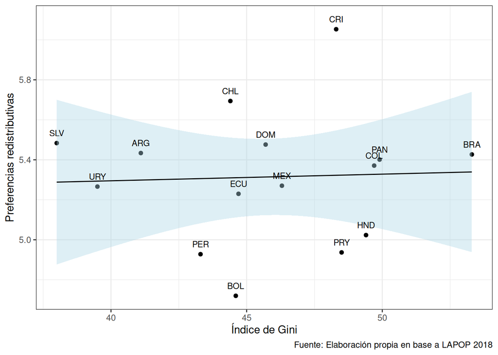

Figura 1: Asociación entre Índice de Gini y Preferencias Redistributivas

```r
grafico1
```

En la Figura 1 se muestra la asociación entre el promedio de preferencia por la redistribución y el nivel de desigualdad ecónomica de los países.

## Tablas

1. Generamos el objeto `tab3` que contiene la información que presentaremos en una tabla.

```r
tab3 <- lapop %>%
  group_by(pais) %>%
  summarise(n = n(),
            media = round(mean(edad, na.rm = TRUE), 1)) %>%
  head(5)
```

2. Creamos la tabla mediante `kable()` especificando las opciones en el chunk.

```r
kable(tab3,
      col.names = c("País", "N", "Edad promedio"),
      align = "lcc")
```

Tabla 1: Edad promedio según país

| País | N | Edad promedio |
| --- | --- | --- |
| ARG | 1528 | 41.8 |
| BOL | 1682 | 39.5 |
| BRA | 1498 | 39.1 |
| CHL | 1638 | 42.2 |
| COL | 1663 | 40.4 |

En la Tabla 1 se muestra la edad promedio de las personas encuestadas en cinco países de la base LAPOP 2018.